# Ohio Key and Polynomials

Earl F Glynn

2022-04-01

Analysis of data in file `key.json` from results in Jupyter notebook `Election-Integrity/Ohio/rlee32/Analysis/Ohio-Analysis-4-Generate-Key.html`

# 1 Setup

## 1.1

## 1.2 Constants

```r
FILE_PREFIX   <- "x"    # no spaces
```

```r
EXCEL_LIMIT <- 2^20
```

```r
stamp <- paste("efg", format(time.1, "%Y-%m-%d %H%M"))
```

## 1.3 Packages

```r
library(tidyverse)
```

Display formatting

```r
library(kableExtra)  # kable_styling
```

```r
#library(IRdisplay)   # display_html (needed in Jupyter notebooks)
```

I/O

```r
library(readxl)      # read_xlsx
library(readr)       # write_csv
library(writexl)     # write_xlsx
```

```r
library(RJSONIO)
```

Graphics

```r
library(scales)      # comma, comma_format
```

## 1.4 ggplot theme

[ggplot Themes Gallery](https://www.datanovia.com/en/blog/ggplot-themes-gallery/)

```r
theme_set(theme_minimal() +

          theme(axis.text             = element_text(size = 10),
                axis.title            = element_text(size = 14),

                plot.caption          = element_text(hjust = c(0.0,1.0)),
                plot.caption.position = "plot",   # R 4.0.0

                plot.title.position   = "plot",
                title                 = element_text(size = 14))
           )
```

```r
COLOR_BAR     <- "skyblue"
COLOR_OUTLINE <- "grey80"
```

## 1.5 Helper functions

```r
Show <- function(data, caption="", bigMark="",
                 height = NULL, width = NULL, ...)
{
  data                                       %>%
  kable("html", caption=caption,
        format.args=list(big.mark=bigMark))  %>%
  kable_styling(bootstrap_options=c("striped", "bordered", "condensed"),
                position="left",
                full_width=FALSE, ...)       %>%
  scroll_box(height = height, width = width) #  %>%
# as.character()                             %>%      # Jupyter Only
# display_html()                                      # Jupyter Only
}
```

```r
createPolynomialText <- function(coef)
{
  signs <- if_else(coef < 0, "-", "+")
  if (signs[1] == "+") signs[1] <- ""

  xvar <- c("", rep("~italic(x)", length(coef)-1) )
  numbers <- sprintf("%.4g", abs(coef))

  exponentSymbol <- c("", "", rep("^", length(coef)-2))
  exponents <- c("", "", 2:(length(coef)-1))

  equation <- paste("italic(y) ==",
                    paste0(signs, " ", numbers, xvar, exponentSymbol, exponents, collapse = " "))
  equation
}
```

# 2 Read `Key` data

```r
JSON <- fromJSON("key.json")

keyRaw <-
  tibble(age = as.numeric( names(JSON) ),
         keyValue = as.numeric(JSON))  %>%
  arrange(age)

dim(keyRaw)
```

```
[1] 88  2
```

Make sure there are no gaps in age

```r
table(diff(keyRaw$age))
```

```
 1
87
```

Restrict to age 100 to match Dr. Frank’s plot as closely as possible.

```r
keyRaw <-
  keyRaw  %>%
  filter(age <= 100)

nrow(keyRaw)
```

```
[1] 83
```

# 3 Ohio Normalized Voter Fraction by Age

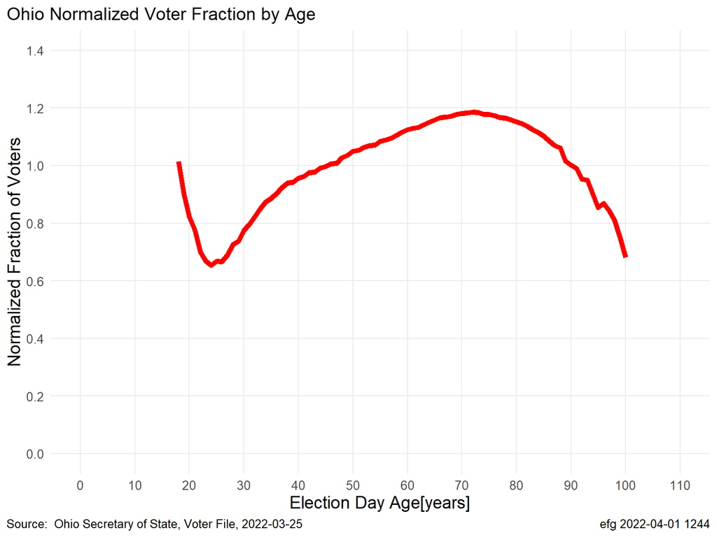

```r
TITLE <- "Ohio Normalized Voter Fraction by Age"

normalizedVoted <-
  ggplot(keyRaw, aes(age, y= keyValue))          +
  geom_line(size = 2, color = "red")             +
  scale_x_continuous(breaks = 0 + 0:11 * 10,
                     limits = c(0, 110) )       +
  scale_y_continuous(breaks = 0:7 * 0.2,
                     limits = c(0, 1.40) )       +
  labs(
        title = TITLE,
        x = "Election Day Age[years]",
        y = "Normalized Fraction of Voters",
        caption = c("Source:  Ohio Secretary of State, Voter File, 2022-03-25",
                     stamp)
      )                                          +
  theme(title = element_text(size = 12),
        panel.grid.minor.x = element_blank(),
        panel.grid.minor.y = element_blank())

print(normalizedVoted)
```

This plot of 83 numbers roughly matches the `Key` shown in the video of the presentation to the Kansas House from 2022-01-20, which is shown below.

# 4 Dr. Frank’s “OH Registration Key”

AFAIK, a more exact comparison is not possible since Dr. Frank does not publish his “key” numbers, nor does he cite the date of the data he obtained from the Ohio Secretary of State.

The data I’m using is likely more than a year later than the data used by Dr. Frank.

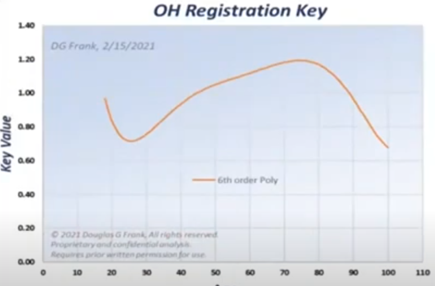

# 5 Polynomial Fits

Dr. Frank uses polynomial regression in Excel to curve fit this data to a polynomial of degree 6. Instead of a polynomial fit, he could have used the original vector of ~83 values by age in subsequent analysis, but he apparently wanted to say a “perfect fit” of a polynomial was the basis of an “algorithm” that explained results. AFAIK,the coefficients of the polynomial have no easy interpretation.

In one video Dr. Frank uses Excel to show a “perfect” polynomial fit of degree 6 explains the data. [I don’t have that citation readily available.]

Let explore how this polynomial might work, including exploring why degree 6 is the “best”. Generally, high degree polynomials cannot be used for extrapolation, but might be useful for interpolation, which is all that is need for this problem.

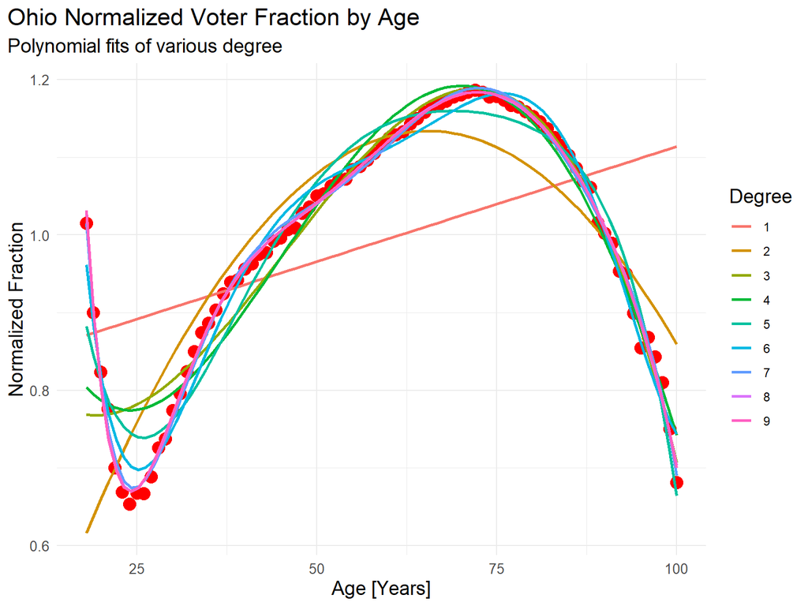

```r
# se = FALSE:  suppress confidence intervals in plot since overlap

ggplot(keyRaw, aes(age, keyValue))  +
  geom_point(size = 4, col = 'red') +
  geom_smooth(method = "lm", formula = y ~ poly(x, 1, raw = TRUE), aes(color =  "1"), se = F) +
  geom_smooth(method = "lm", formula = y ~ poly(x, 2, raw = TRUE), aes(color =  "2"), se = F) +
  geom_smooth(method = "lm", formula = y ~ poly(x, 3, raw = TRUE), aes(color =  "3"), se = F) +
  geom_smooth(method = "lm", formula = y ~ poly(x, 4, raw = TRUE), aes(color =  "4"), se = F) +
  geom_smooth(method = "lm", formula = y ~ poly(x, 5, raw = TRUE), aes(color =  "5"), se = F) +
  geom_smooth(method = "lm", formula = y ~ poly(x, 6, raw = TRUE), aes(color =  "6"), se = F) +
  geom_smooth(method = "lm", formula = y ~ poly(x, 7, raw = TRUE), aes(color =  "7"), se = F) +
  geom_smooth(method = "lm", formula = y ~ poly(x, 8, raw = TRUE), aes(color =  "8"), se = F) +
  geom_smooth(method = "lm", formula = y ~ poly(x, 9, raw = TRUE), aes(color =  "9"), se = F) +
  labs(title = TITLE,
       subtitle = "Polynomial fits of various degree",
       x = "Age [Years]",
       y = "Normalized Fraction",
       color = "Degree")
```

**There is nothing remarkable about how these polynomial fits are nearly perfect.** This is common with various curve fitting algorithms, but the curve fitting process offers few insights about the nature of the curve.

## 5.1 Akaike Information Criterion (AIC)

Use AIC to try to prevent overfitting.

[Video with explanation](https://www.youtube.com/watch?v=0qPFRMJxm-k) of using AIC with polynomial regression.

The best-fit model according to AIC is the one that explains the greatest amount of variation using the fewest possible independent variables.

We want a high enough degree for curvature/wiggliness, but not too high that would overfit the data.

We need to be cautious using [higher degree polynomials (n > 4) since that may lead to over-fitting](https://datascienceplus.com/fitting-polynomial-regression-r/). Over-fitting happens when your model is picking up the noise instead of the signal

Use abbreviated variable names

```r
x <- keyRaw$age
y <- keyRaw$keyValue
```

```r
fits <- list()
```

```r
for (degree in 1:9)
{
  newfit <- lm(y ~ poly(x, degree, raw = TRUE))
  fits[[degree]] <- newfit
}

length(fits)
```

```
[1] 9
```

```r
unlist(lapply(fits, AIC))
```

```
[1]  -82.99028 -179.80566 -259.92665 -264.75861 -302.92168 -381.98636 -499.23712
[8] -516.81140 -516.37622
```

## 5.2 R-Squared and Adjust R-Squared Values by Degree

[See info here](https://stats.stackexchange.com/questions/48703/what-is-the-adjusted-r-squared-formula-in-lm-in-r-and-how-should-it-be-interpret) about adjusted R-Squared values in R.

```r
extractRSquared <- function(degree, x)
{
  tibble(degree        = degree,
         r.squared     = summary(x[[degree]])$r.squared,
         adj.r.squared = summary(x[[degree]])$adj.r.squared)
}
```

```r
rsqData <-
  1:length(fits)  %>%
  map_df(extractRSquared, fits)

rsqData %>%  Show()
```

| degree | r.squared | adj.r.squared |
| --- | --- | --- |
| 1 | 0.2007707 | 0.1909037 |
| 2 | 0.7569903 | 0.7509151 |
| 3 | 0.9096499 | 0.9062189 |
| 4 | 0.9167891 | 0.9125218 |
| 5 | 0.9487105 | 0.9453800 |
| 6 | 0.9806865 | 0.9791618 |
| 7 | 0.9954092 | 0.9949808 |
| 8 | 0.9963737 | 0.9959817 |
| 9 | 0.9964414 | 0.9960027 |

Here both $R^2$ values are monotonically increasing, suggesting a higher degree is a “better” fit. However, there is little improvement from degree 7 or higher.

# 6 Certain polynomial degree fits

Including 95% confidence intervals

## 6.1 Degree 5

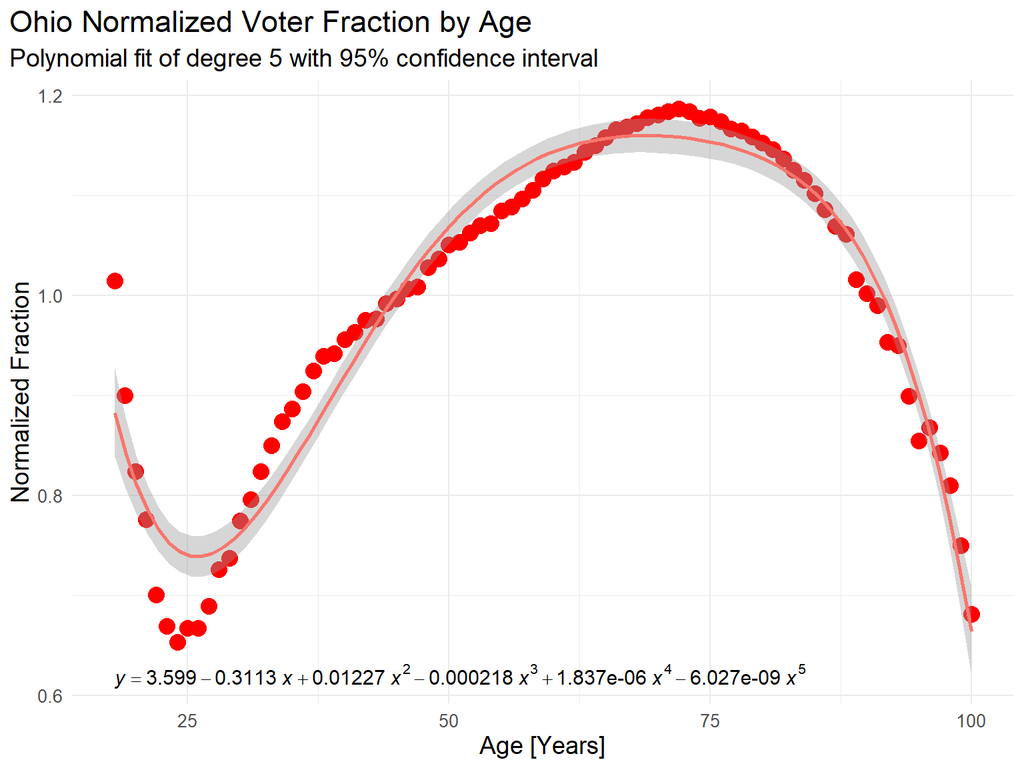

```r
ggplot(keyRaw, aes(age, keyValue))       +
  geom_point(size = 4, col = 'red')      +
  geom_smooth(method = "lm", formula = y ~ poly(x, 5, raw = TRUE), aes(color =  "5")) +
  labs(title = TITLE,
       subtitle = "Polynomial fit of degree 5 with 95% confidence interval",
       x = "Age [Years]",
       y = "Normalized Fraction",
       color = "Degree")                 +
  annotate(
            "text",
            x = 18,
            y = 0.62,
            label = createPolynomialText(fits[[5]]$coefficients %>% as.numeric()),
            hjust = 0,
            size  = 4,
            parse = TRUE
          )                              +
  theme(legend.position = "none")
```

```r
summary(fits[[5]])
```

```
Call:
lm(formula = y ~ poly(x, degree, raw = TRUE))

Residuals:
      Min        1Q    Median        3Q       Max
-0.092112 -0.022410  0.003794  0.021963  0.132460

Coefficients:
                               Estimate Std. Error t value Pr(>|t|)
(Intercept)                   3.599e+00  3.481e-01  10.338 3.29e-16 ***
poly(x, degree, raw = TRUE)1 -3.113e-01  3.802e-02  -8.187 4.43e-12 ***
poly(x, degree, raw = TRUE)2  1.227e-02  1.536e-03   7.992 1.05e-11 ***
poly(x, degree, raw = TRUE)3 -2.180e-04  2.896e-05  -7.528 8.22e-11 ***
poly(x, degree, raw = TRUE)4  1.837e-06  2.575e-07   7.136 4.59e-10 ***
poly(x, degree, raw = TRUE)5 -6.027e-09  8.706e-10  -6.923 1.16e-09 ***
---
Signif. codes:  0 '***' 0.001 '**' 0.01 '*' 0.05 '.' 0.1 ' ' 1

Residual standard error: 0.03723 on 77 degrees of freedom
Multiple R-squared:  0.9487,    Adjusted R-squared:  0.9454
F-statistic: 284.9 on 5 and 77 DF,  p-value: < 2.2e-16
```

```r
fits[[5]]$coefficients
```

```
                 (Intercept) poly(x, degree, raw = TRUE)1
                3.598943e+00                -3.113124e-01
poly(x, degree, raw = TRUE)2 poly(x, degree, raw = TRUE)3
                1.227467e-02                -2.180073e-04
poly(x, degree, raw = TRUE)4 poly(x, degree, raw = TRUE)5
                1.837256e-06                -6.026864e-09
```

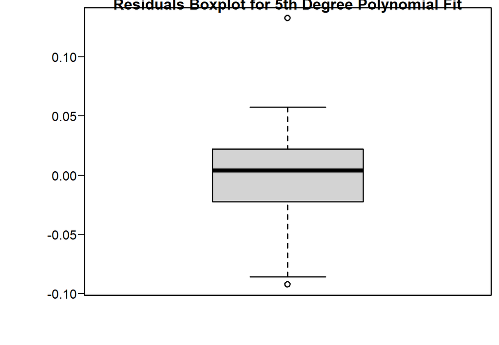

```r
boxplot(fits[[5]]$residuals, main = "Residuals Boxplot for 5th Degree Polynomial Fit" )
```

Fivenum summary: min, Q1, Q2 (median), Q3, max

```r
fivenum(fits[[5]]$residuals)
```

```
           7           74           67           80            1
-0.092112243 -0.022409592  0.003794103  0.021962918  0.132459804
```

## 6.2 Degree 6

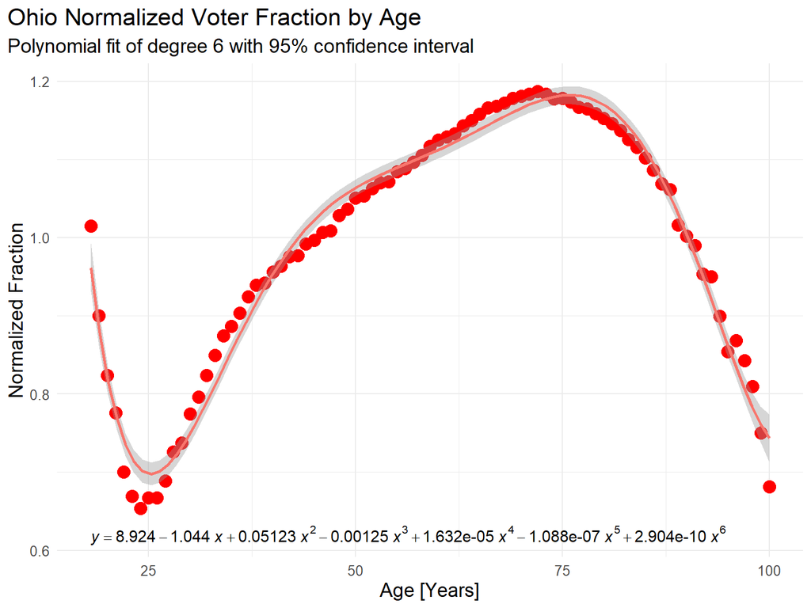

```r
ggplot(keyRaw, aes(age, keyValue))  +
  geom_point(size = 4, col = 'red') +
  geom_smooth(method = "lm", formula = y ~ poly(x, 6, raw = TRUE), aes(color =  "6")) +
  labs(title = TITLE,
       subtitle = "Polynomial fit of degree 6 with 95% confidence interval",
       x = "Age [Years]",
       y = "Normalized Fraction",
       color = "Degree")            +
  annotate(
            "text",
            x = 18,
            y = 0.62,
            label = createPolynomialText(fits[[6]]$coefficients %>% as.numeric()),
            hjust = 0,
            size  = 4,
            parse = TRUE
          )                              +
  theme(legend.position = "none")
```

```r
summary(fits[[6]])
```

[output not shown]

```r
fits[[6]]$coefficients
```

```
                 (Intercept) poly(x, degree, raw = TRUE)1
                8.923901e+00                -1.043729e+00
poly(x, degree, raw = TRUE)2 poly(x, degree, raw = TRUE)3
                5.123154e-02                -1.250307e-03
poly(x, degree, raw = TRUE)4 poly(x, degree, raw = TRUE)5
                1.632192e-05                -1.088456e-07
poly(x, degree, raw = TRUE)6
                2.904484e-10
```

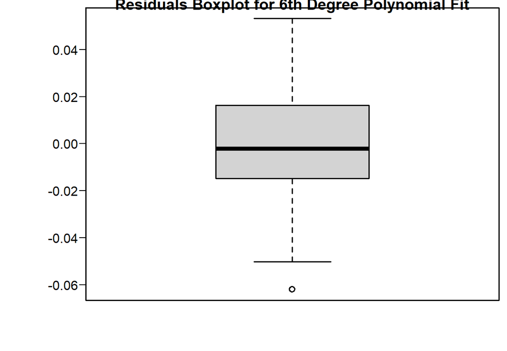

```r
boxplot(fits[[6]]$residuals, main = "Residuals Boxplot for 6th Degree Polynomial Fit" )
```

```r
fivenum(fits[[6]]$residuals)
```

```
          83           60           40           46            1
-0.061919766 -0.014687619 -0.002186387  0.016333322  0.053209992
```

## 6.3 Degree 7

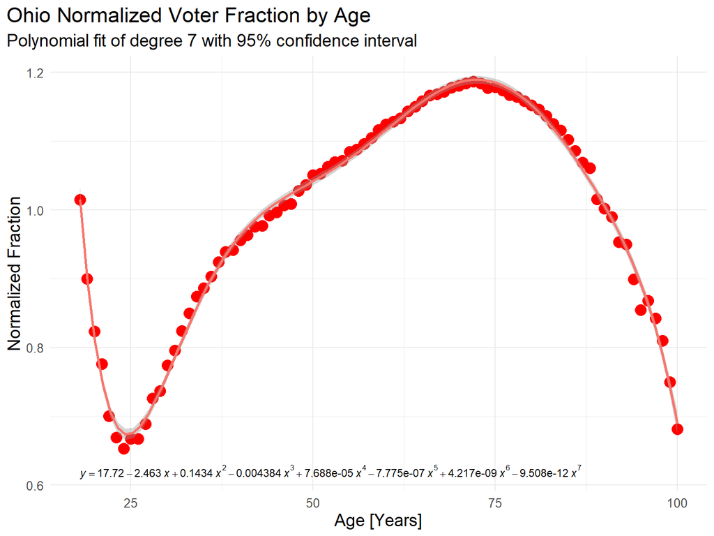

```r
ggplot(keyRaw, aes(age, keyValue))  +
  geom_point(size = 4, col = 'red') +
  geom_smooth(method = "lm", formula = y ~ poly(x, 7, raw = TRUE), aes(color =  "7")) +
  labs(title = TITLE,
       subtitle = "Polynomial fit of degree 7 with 95% confidence interval",
       x = "Age [Years]",
       y = "Normalized Fraction",
       color = "Degree")            +
  annotate(
            "text",
            x = 18,
            y = 0.62,
            label = createPolynomialText(fits[[7]]$coefficients %>% as.numeric()),
            hjust = 0,
            size  = 3,
            parse = TRUE
          )                              +
  theme(legend.position = "none")
```

```r
summary(fits[[7]])
```

```
Call:
lm(formula = y ~ poly(x, degree, raw = TRUE))

Residuals:
      Min        1Q    Median        3Q       Max
-0.038741 -0.007470  0.000270  0.008004  0.023727

Coefficients:
                               Estimate Std. Error t value Pr(>|t|)
(Intercept)                   1.772e+01  6.219e-01   28.49   <2e-16 ***
poly(x, degree, raw = TRUE)1 -2.463e+00  9.765e-02  -25.22   <2e-16 ***
poly(x, degree, raw = TRUE)2  1.434e-01  6.201e-03   23.13   <2e-16 ***
poly(x, degree, raw = TRUE)3 -4.384e-03  2.073e-04  -21.16   <2e-16 ***
poly(x, degree, raw = TRUE)4  7.688e-05  3.956e-06   19.43   <2e-16 ***
poly(x, degree, raw = TRUE)5 -7.775e-07  4.335e-08  -17.94   <2e-16 ***
poly(x, degree, raw = TRUE)6  4.217e-09  2.535e-10   16.64   <2e-16 ***
poly(x, degree, raw = TRUE)7 -9.508e-12  6.130e-13  -15.51   <2e-16 ***
---
Signif. codes:  0 '***' 0.001 '**' 0.01 '*' 0.05 '.' 0.1 ' ' 1

Residual standard error: 0.01129 on 75 degrees of freedom
Multiple R-squared:  0.9954,    Adjusted R-squared:  0.995
F-statistic:  2323 on 7 and 75 DF,  p-value: < 2.2e-16
```

```r
fits[[7]]$coefficients
```

```
                 (Intercept) poly(x, degree, raw = TRUE)1
                1.771594e+01                -2.463097e+00
poly(x, degree, raw = TRUE)2 poly(x, degree, raw = TRUE)3
                1.434105e-01                -4.384331e-03
poly(x, degree, raw = TRUE)4 poly(x, degree, raw = TRUE)5
                7.687837e-05                -7.774660e-07
poly(x, degree, raw = TRUE)6 poly(x, degree, raw = TRUE)7
                4.217096e-09                -9.507620e-12
```

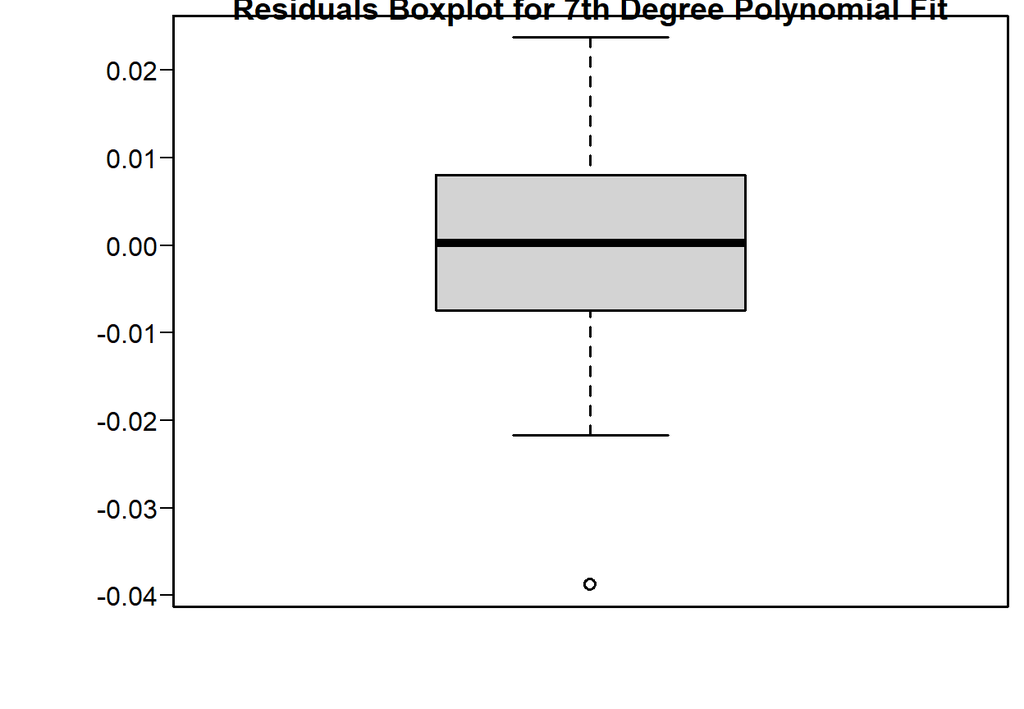

```r
boxplot(fits[[7]]$residuals, main = "Residuals Boxplot for 7th Degree Polynomial Fit" )
```

```r
fivenum(fits[[7]]$residuals)
```

```
           78            59            32            66             4
-0.0387411407 -0.0074695504  0.0002704887  0.0080038082  0.0237271922
```

# 7 Epilog

## 7.1

Processing time: 5.2 secs

2022-04-01 1245